# projet App Stat

Elyas Ben Jebara, Guillaume Maurin

2024-03-11

# I. Introduction:

À l’ère de la numérisation, où les réseaux sociaux et plus largement Internet deviennent les premiers vecteurs d’information, la consultation d’articles en ligne est devenue une pratique courante, reléguant les supports papier à un rôle secondaire. Dans ce contexte, la quantité de partages d’un article sur les réseaux sociaux est devenue un indicateur de son influence et de sa portée. Reconnaissant cette tendance, la recherche menée par Fernandes, Vinagre et Cortez en 2015 a mis en lumière l’importance des métriques en ligne, en collectant et en analysant une vaste collection de données sur plus de 35 000 articles. Ces données, extraites de la base Online News Popularity de l’UCI, incluent des informations telles que le style d’écriture, la longueur des articles, le jour de publication et, crucial pour notre étude, le nombre de partages des articles. Notre but est d’approfondir cette recherche, en se focalisant sur la variable « partages » comme indicateur de popularité, pour la modéliser statistiquement et prédire quel contenu captivera l’audience. Nous cherchons à comprendre quelles variables, parmi celles issues de la base de données Online News Popularity, ont le plus d’impact sur la popularité d’un article en ligne, afin de pouvoir anticiper le niveau d’engagement que cet article est susceptible de générer une fois publié. L’objectif est de construire des modèles pour estimer la popularité future d’un article, sur la base de caractéristiques quantifiables, contribuant ainsi à optimiser la création de contenu. Notre étude s’inscrit dans le sillage de l’analyse pionnière de Kelwin Fernandes, Pedro Vinagre et Paulo Cortez intitulée “A proactive intelligent Decision support system for Predicting the popularity of online news”, qui examine l’impact des caractéristiques des articles sur leur popularité. Cette recherche a porté sur des articles issus de Mashable, plateforme mondiale de divertissement et d’information numérique fondée en 2005, connue pour couvrir les dernières tendances en technologie, culture numérique, et divertissement. . La recherche met en avant l’influence du style d’écriture, de la longueur des articles, et de la richesse multimédia sur les interactions sociales. D’autres études, telles que celles de Ting et Brochu (2017) et Kari et al. (2016), ont également exploré l’utilisation de ces données pour approfondir la compréhension des mécanismes sous-jacents à la popularité en ligne, en appliquant des méthodes avancées d’analyse et de prédiction.

La littérature souligne l’importance capitale du partage, où un nombre de partages important est synonyme d’une plus grande influence. De plus, la caractérisation des styles d’écriture ouvre de nouvelles possibilités pour comprendre comment cet élément influence l’engagement et la réceptivité du public. Bien que l’accès direct à certaines études complémentaires soit restreint, les discussions générales dans le domaine confirment que les caractéristiques qualitatives et quantitatives du contenu des articles peuvent significativement affecter leur popularité.

Notre projet se concentre sur une question fondamentale : **Comment les différentes caractéristiques des articles en ligne, telles que leur contenu, style, et éléments visuels, influencent-ils le nombre de leurs partages sur les réseaux sociaux ?**

Nous entamons notre projet par une analyse exploratoire pour comprendre la distribution des variables et leurs relations, ce qui est essentiel pour identifier les facteurs influençant le plus les partages d’articles. Nous appliquerons ensuite une variété de techniques de modélisation, allant de la régression linéaire aux forêts aléatoires et méthodes plus sophistiquées comme le KNN, pour prédire la popularité des articles. L’expérimentation avec un modèle de clustering K-means nous permettra également de segmenter les articles, visant à affiner nos prédictions. L’évaluation des modèles par la validation croisée nous guidera vers les techniques les plus performantes, avec pour objectif final de formuler des recommandations basées sur les caractéristiques déterminant la popularité des articles en ligne.

# II. Présentation, et analyse descriptive des données:

## A. Importation et présentation de la base de données:

Notre base de données, “Online News Popularity”, est issue de l’UCI Machine Learning Repository. Elle a été collectée depuis le site internet Mashable, qui recense des milliers d’articles. Cette base de donnée compile des informations sur plus de 39,000 articles publiés par Mashable sur deux ans, avec pour objectif de prédire le nombre de partages sur les réseaux sociaux. Cette base contient 61 variables, dont le style d’écriture, la longueur des articles, et le nombre de partages (“shares”). Utilisée dans diverses recherches, elle a servi à explorer l’impact des caractéristiques des articles sur leur popularité en ligne.

```
## # A tibble: 6 × 61
##   url                  timedelta n_tokens_title n_tokens_content n_unique_tokens
##   <chr>                    <dbl>          <dbl>            <dbl>           <dbl>
## 1 http://mashable.com…       731             12              219           0.664
## 2 http://mashable.com…       731              9              255           0.605
## 3 http://mashable.com…       731              9              211           0.575
## 4 http://mashable.com…       731              9              531           0.504
## 5 http://mashable.com…       731             13             1072           0.416
## 6 http://mashable.com…       731             10              370           0.560
## # ℹ 56 more variables: n_non_stop_words <dbl>, n_non_stop_unique_tokens <dbl>,
## #   num_hrefs <dbl>, num_self_hrefs <dbl>, num_imgs <dbl>, num_videos <dbl>,
## #   average_token_length <dbl>, num_keywords <dbl>,
## #   data_channel_is_lifestyle <dbl>, data_channel_is_entertainment <dbl>,
## #   data_channel_is_bus <dbl>, data_channel_is_socmed <dbl>,
## #   data_channel_is_tech <dbl>, data_channel_is_world <dbl>, kw_min_min <dbl>,
## #   kw_max_min <dbl>, kw_avg_min <dbl>, kw_min_max <dbl>, kw_max_max <dbl>, …
```

```
## [1] 5450   61
```

```
## [1] 39644    61
```

L’élimination des valeurs aberrantes est une étape cruciale dans la préparation des données pour l’analyse et la prédiction, particulièrement lorsqu’il s’agit d’étudier l’impact de diverses caractéristiques sur la popularité des articles en ligne. Les outliers peuvent fausser les résultats d’une analyse en exerçant une influence disproportionnée sur la moyenne, la médiane, et d’autres statistiques descriptives, ainsi que sur les modèles prédictifs. Pour identifier et exclure ces valeurs atypiques, nous avons adopté une méthode basée sur l’écart interquartile (IQR). En calculant l’IQR pour chaque variable numérique non binaire et en définissant des seuils au-delà desquels les observations sont considérées comme des outliers (typiquement, en dessous du premier quartile moins 1.5 fois l’IQR et au-dessus du troisième quartile plus 1.5 fois l’IQR), nous avons pu filtrer ces valeurs atypiques. Cette approche a permis de réduire notre ensemble de données à 5450 observations, offrant ainsi une base plus cohérente et représentative pour la prédiction du nombre de partages d’un article. Cette taille de données réduite et plus homogène est essentielle pour augmenter la précision et la fiabilité de nos modèles prédictifs, en nous assurant que ces derniers reflètent les tendances réelles plutôt que d’être influencés par des cas extrêmes non représentatifs.

## B. La variable d’interet (shares):

```
##    Min. 1st Qu.  Median    Mean 3rd Qu.    Max.
##       1     946    1400    3395    2800  843300
```

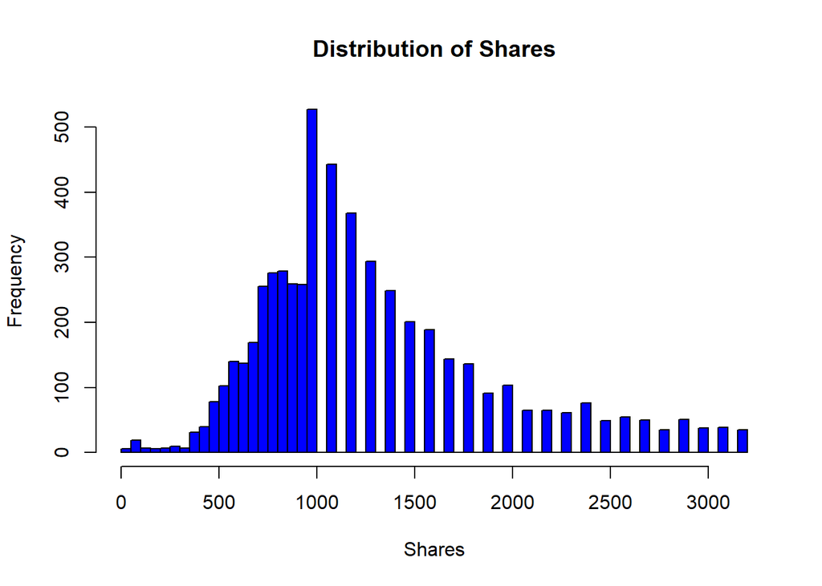

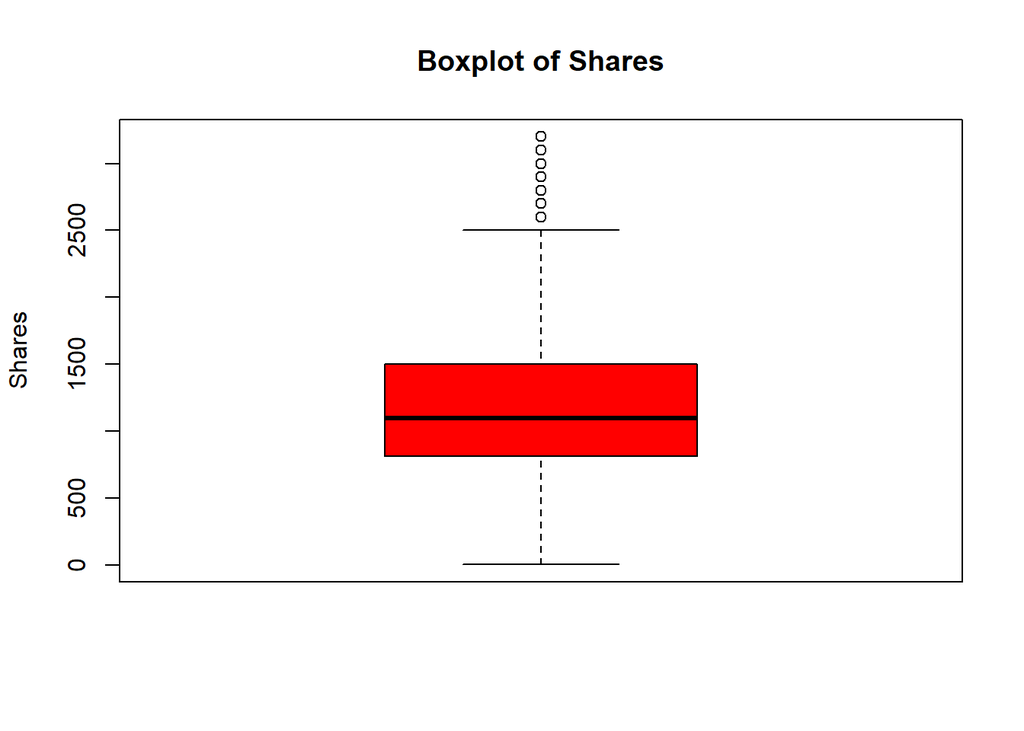

```
##    Min. 1st Qu.  Median    Mean 3rd Qu.    Max.
##       5     812    1100    1239    1500    3200
```

La variable “shares” joue un rôle central dans notre analyse, en tant qu’indicateur direct du degré de popularité d’un article sur les réseaux sociaux.

Initialement, la distribution de cette variable révèle une large variété dans le nombre de partages, s’étendant de 1 à 843,300, avec une médiane à 1400 et une moyenne significativement plus élevée à 3395, ce qui indique une distribution fortement asymétrique avec une présence marquée de valeurs extrêmes.

Pour améliorer la précision de nos prédictions et minimiser l’effet des valeurs aberrantes, une démarche de nettoyage des données a été entreprise. En calculant l’écart interquartile (IQR) et en définissant des bornes spécifiques, nous avons filtré les données pour concentrer notre analyse sur une gamme de partages plus représentative de la majorité des articles, réduisant ainsi le maximum à 3200 partages. Cette démarche méthodique nous permet de disposer d’une distribution ajustée, avec une médiane ajustée à 1100 partage et une moyenne à 1239.

## C. Catégorisation des variables et analyses univariées:

Dans notre étude, pour mieux comprendre nos variables, nous avons catégorisé les variables de la base de données “Online News Popularity” en cinq groupes principaux pour une analyse approfondie de leur impact sur la popularité des articles en ligne. Ces groupes sont définis comme les caractéristiques liées au contenu de l’article, les éléments multimédias intégrés, la présence et le type de liens, les détails temporels relatifs à la publication, et enfin les aspects stylistiques et thématiques du texte.

### 1. Contenu de l’article:

```
## # A tibble: 7 × 2
##   Variable                 Description
##   <chr>                    <chr>
## 1 n_tokens_title           Number of words in the title
## 2 n_tokens_content         Number of words in the content
## 3 n_unique_tokens          Rate of unique words in the content
## 4 n_non_stop_words         Rate of non-stop words in the content
## 5 n_non_stop_unique_tokens Rate of unique non-stop words in the content
## 6 average_token_length     Average length of the words in the content
## 7 num_keywords             Number of keywords in the metadata
```

La première catégorie, “Contenu de l’article”, se concentre sur la structure textuelle et la richesse linguistique des articles. Elle englobe le nombre de mots dans le titre et le contenu, le taux de mots uniques, ainsi que la présence de mots non-stop, indiquant la diversité et la densité du texte. Cette catégorie inclut également la longueur moyenne des mots et le nombre de mots-clés.

*n_tokens_title* : Nombre de mots dans le titre *n_tokens_content* : Nombre de mots dans le contenu *n_unique_tokens* : Taux de mots uniques dans le contenu *n_non_stop_words* : Taux de mots non-stop dans le contenu *n_non_stop_unique_tokens* : Taux de mots non-stop uniques dans le contenu *average_token_length* : Longueur moyenne des mots dans le contenu *num_keywords* : Nombre de mots-clés dans les métadonnées

Analyses de la variable *nombre de mots dans le titre* :

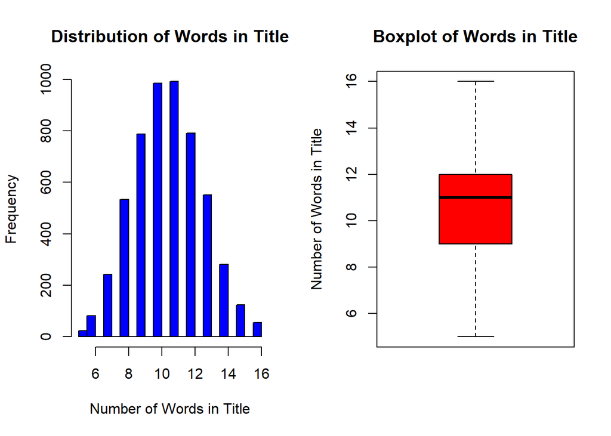

L’histogramme montre une distribution concentrée du nombre de mots dans les titres d’articles, avec une fréquence maximale pour les titres contenant entre 9 et 12 mots. Cela indique une préférence pour les titres concis et informatifs dans la rédaction d’articles en ligne. Le boxplot associé révèle que la moitié (séparée par le trait noir de la médiane) des données se situe dans une plage étroite, démontrant une proximité dans la longueur des titres choisis par les rédacteurs, avec peu d’outliers, qui indiqueraient des titres extrêmement courts ou longs.

Analyses de la variable *nombre de mots dans l’article* :

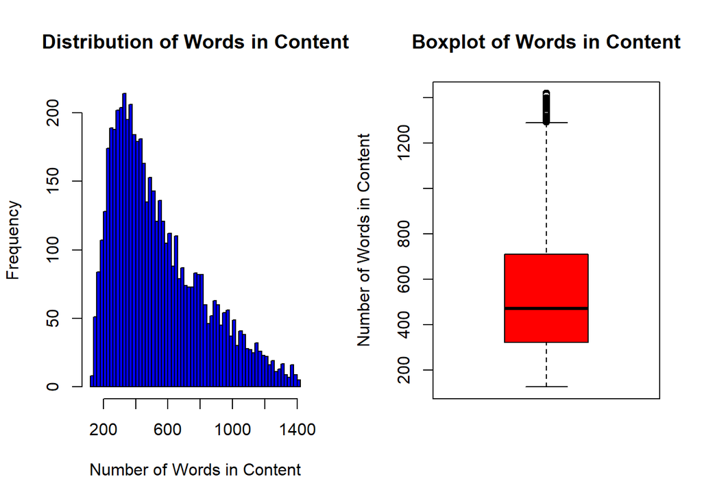

Analyses de la variable *taux de mots unique dans l’article* :

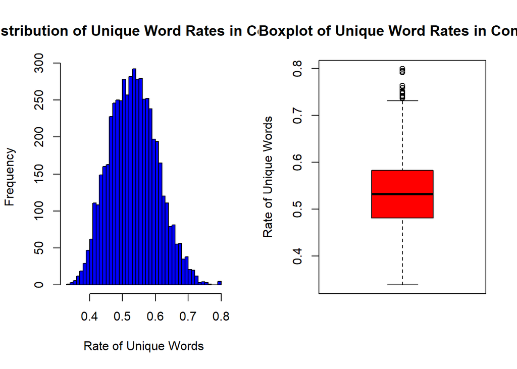

L’histogramme du *taux de mots unique dans l’article* dans les articles révèle une distribution empirique centrée autour d’une valeur médiane, suggérant une tendance générale vers une diversité de vocabulaire modérée à élevée. Le boxplot souligne cette centralité, avec une médiane proche de 0.5 et une répartition relativement homogène, malgré quelques valeurs extrêmes. Ces données indiquent que les rédacteurs maintiennent une certaine richesse lexicale dans leur contenu, sans pour autant recourir excessivement à un vocabulaire trop varié, ce qui pourrait refléter un équilibre entre l’accessibilité du contenu et la sophistication linguistique, peut-être pour évoquer des sujets plus techniques.

Analyses de la variable *nombre de mots clef recensés dans l’article depuis les métadonnées* :

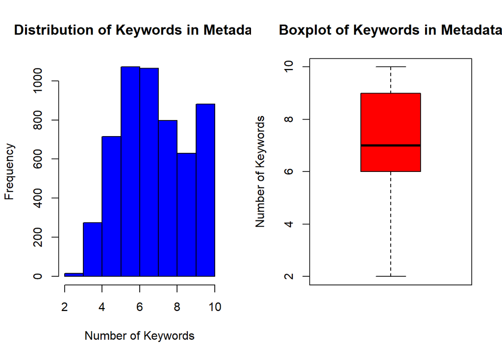

L’histogramme et le boxplot pour la variable *nombre de mots clef recensés dans l’article depuis les métadonnées* montrent une préférence pour une quantité modérée à élevée de mots-clés par article, avec la majorité des articles utilisant entre 4 et 10 mots-clés. La distribution semble légèrement asymétrique vers un nombre élevé de mots-clés, tandis que la médiane, indiquée par le boxplot, suggère que la moitié des articles contient un nombre de mots-clés proche de 7. Peu de valeurs extrêmes sont observées, ce qui indique une relative uniformité dans l’approche de l’utilisation des mots-clés par les rédacteurs pour la description et le référencement des articles.

Les analyses univariées des variables de la catégorie **Contenu de l’article** suggèrent plusieurs tendances éditoriales dans la base de données “Online News Popularity”. Il y a une tendance vers des articles plus courts, ce qui peut refléter une stratégie pour maintenir l’engagement du lecteur dans un environnement numérique où l’attention est limitée. La diversité lexicale des articles est modérée, indiquant une balance entre accessibilité et profondeur du contenu. Enfin, l’utilisation stratégique des mots-clés suggère une conscience des impératifs de référencement. Ces variables dépeignent une image de la rédaction en ligne qui est ciblée et adaptée aux comportements de consommation de contenu sur internet.

### 2. Multimédia

La deuxième catégorie, **Multimédia**, aborde la dimension visuelle et interactive des articles en ligne à travers le nombre d’images et de vidéos intégrées. Cette catégorie reflète l’importance des éléments multimédias dans l’enrichissement du contenu et l’engagement du lecteur, suggérant que la présence de supports visuels peut significativement influencer la popularité et le partage des articles sur les réseaux sociaux.

*num_imgs* : Nombre d’images *num_videos* : Nombre de vidéos

```
## # A tibble: 2 × 2
##   Variable   Description
##   <chr>      <chr>
## 1 num_imgs   Number of images
## 2 num_videos Number of videos
```

```
##    Min. 1st Qu.  Median    Mean 3rd Qu.    Max.
##   0.000   1.000   1.000   1.416   2.000   6.000
```

```
##    Min. 1st Qu.  Median    Mean 3rd Qu.    Max.
##  0.0000  0.0000  0.0000  0.3235  1.0000  2.0000
```

Analyses de la variable *nombre d’image dans l’article* :

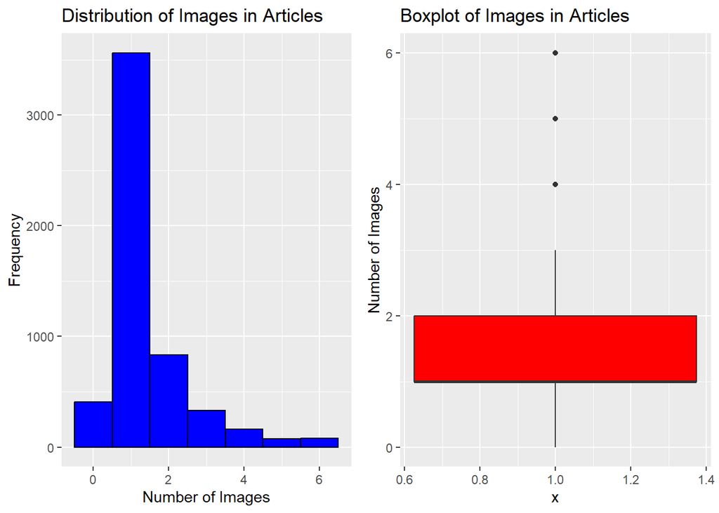

Analyses de la variable *nombre de videos dans l’article* :

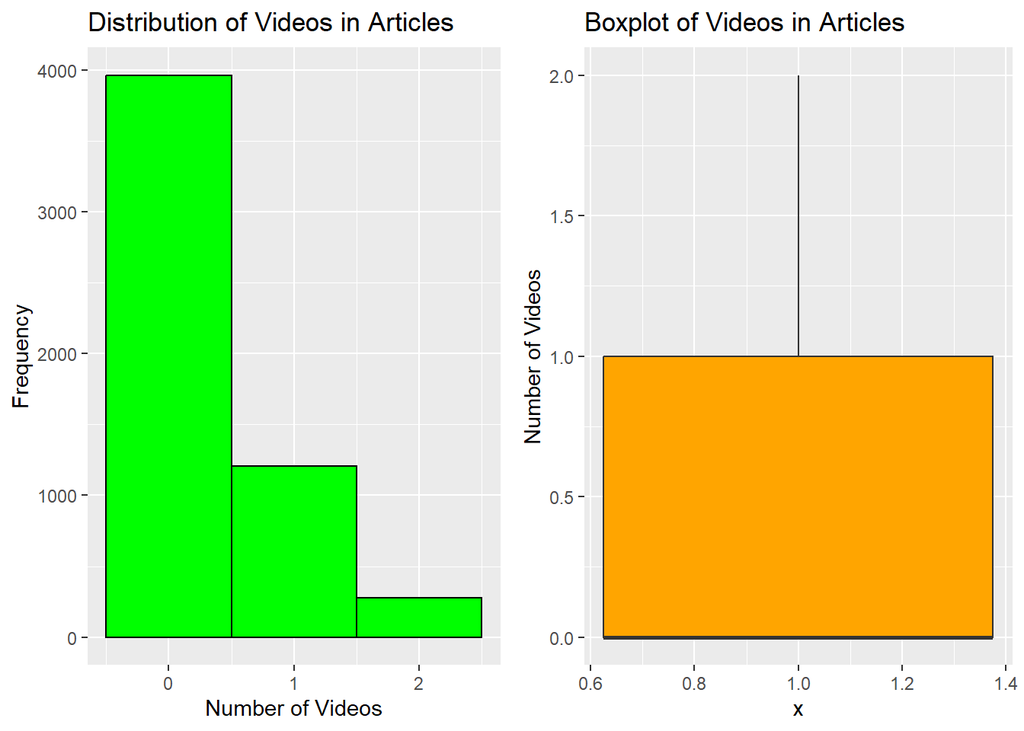

Les distributions du nombre d’images et de vidéos dans les articles montrent des préférences éditoriales distinctes. Pour les images, la plupart des articles comprennent une ou deux images, avec une moyenne légèrement supérieure à un, indiquant une tendance à illustrer les contenus sans encombrer visuellement le texte. Le boxplot confirme cette tendance en montrant peu de valeurs aberrantes, ce qui suggère une norme établie dans l’usage d’images.

### 3. Liens

La troisième catégorie, **Liens**, se penche sur l’intégration et la pertinence des hyperliens dans les articles, à travers deux variables distinctes : *le nombre total de liens* (num_hrefs) et *le nombre de liens pointant vers d’autres articles de Mashable* (num_self_hrefs). Cette catégorie souligne l’importance de la connectivité et de l’autoréférence dans le contenu, indiquant comment les articles s’insèrent dans un réseau plus large d’informations et contribuent à l’écosystème de contenu d’un média, pouvant ainsi influencer leur visibilité et leur partage.

*num_hrefs* : Nombre de liens *num_self_hrefs* : Nombre de liens vers d’autres articles publiés par Mashable

```
## # A tibble: 2 × 2
##   Variable       Description
##   <chr>          <chr>
## 1 num_hrefs      Number of links
## 2 num_self_hrefs Number of links to other articles published by Mashable
```

On va s’interesser à la variable **nombre de lien référencés dans l’article** pour une étude univariée.

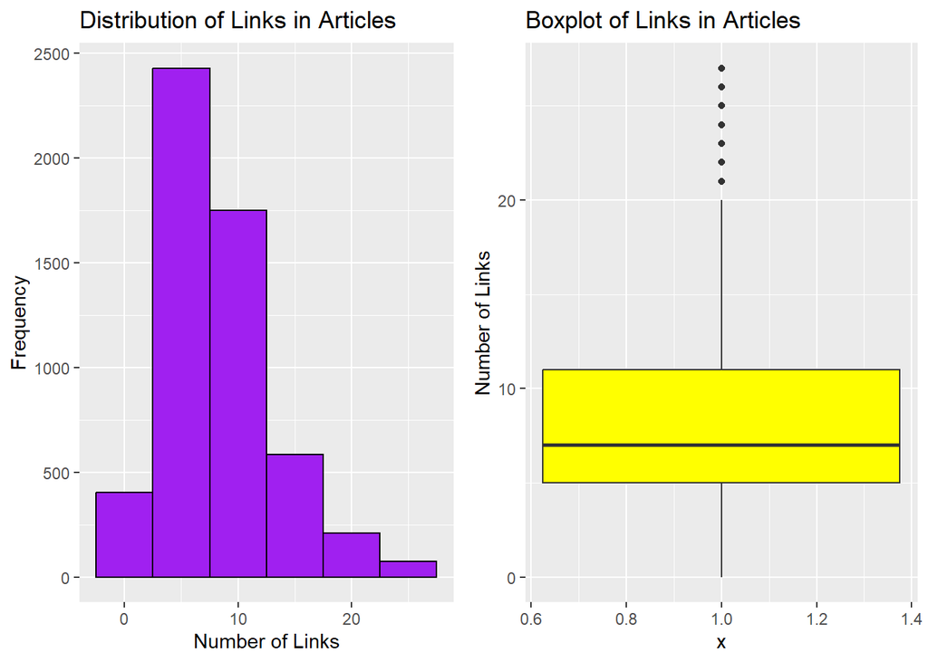

L’histogramme de la distribution du *nombre de liens par article* montre une prédominance d’articles avec un petit nombre de liens, la majorité ayant moins de 10 liens. Cela pourrait indiquer une stratégie de contenu axée sur l’autonomie de l’article ou des considérations de référencement SEO ciblées. Le boxplot révèle que, bien que l’étendue des données soit large, avec des outliers représentant des articles avec un nombre élevé de liens, la concentration centrale se situe bien en dessous, indiquant que les valeurs extrêmes ne sont pas la norme. Cette approche prudente de l’inclusion de liens externes pourrait viser à garder les lecteurs engagés sur l’article actuel plutôt que de les diriger vers d’autres sites. Il faut également prendre en compte la nécessité de citer ses sources, pour des articles plus techniques, qui peut ainsi augmenter la quantité de liens.

### 4. Temporalité de la publication

La quatrième catégorie, intitulée **Temporalité de la Publication**, se concentre sur les aspects temporels et de programmation de publication des articles. Cette catégorie comprend plusieurs variables qui fournissent des informations sur le moment de la publication de chaque article, ainsi que sur la durée écoulée depuis sa publication jusqu’à l’acquisition des données.

*timedelta* : Jours entre la publication de l’article et l’acquisition des données *weekday_is_monday* : L’article a-t-il été publié un lundi ? *weekday_is_tuesday* : Un mardi ? *weekday_is_wednesday* : Un mercredi ? *weekday_is_thursday* : Un jeudi ? *weekday_is_friday* : Un vendredi ? *weekday_is_saturday* : Un samedi ? *weekday_is_sunday* : Un dimanche ? *is_weekend* : L’article a-t-il été publié le weekend ?

```
## # A tibble: 9 × 2
##   Variable             Description
##   <chr>                <chr>
## 1 timedelta            Days between the article publication and the dataset acq…
## 2 weekday_is_monday    Was the article published on a Monday?
## 3 weekday_is_tuesday   Was the article published on a Tuesday?
## 4 weekday_is_wednesday Was the article published on a Wednesday?
## 5 weekday_is_thursday  Was the article published on a Thursday?
## 6 weekday_is_friday    Was the article published on a Friday?
## 7 weekday_is_saturday  Was the article published on a Saturday?
## 8 weekday_is_sunday    Was the article published on a Sunday?
## 9 is_weekend           Was the article published on the weekend?
```

On va s’intéresser à la variable *le nombre de jours entre la publication de l’article et l’acquisition des données* :

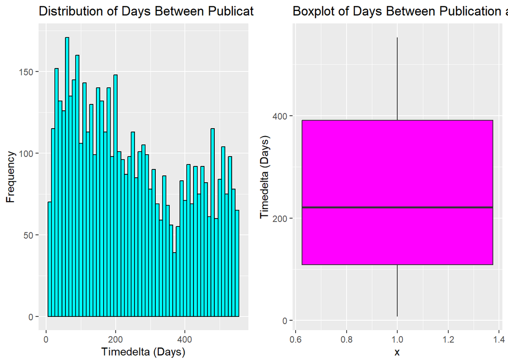

On va maintenant voir quel jour les articles sont d’habitude publié et cela en analysant les variable binaires du **jour de la publication** :

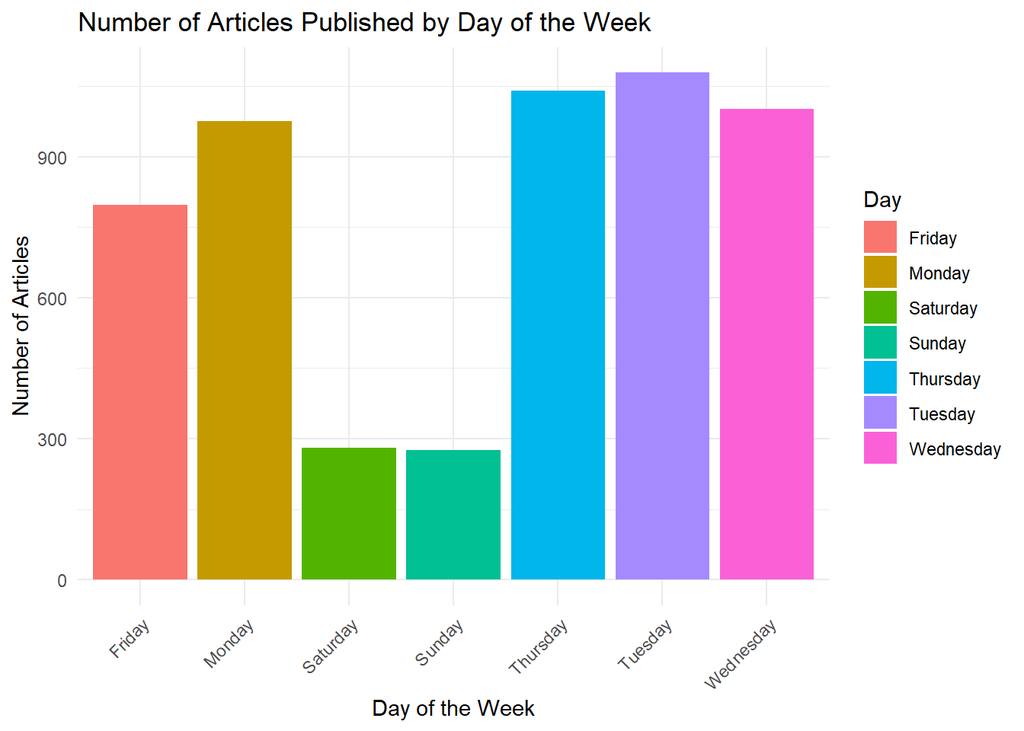

Ce graphique en barres illustre le nombre d’articles publiés par jour de la semaine, révélant des tendances de publication marquées. Les articles sont le plus fréquemment publiés en milieu de semaine, avec un pic le mardi, suivi de près par le jeudi et le mercredi, puis par le lundi. Le nombre diminue le weekend, avec le samedi et le dimanche affichant le nombre le plus bas de publications. Cette distribution peut être influencée par des stratégies éditoriales visant à capter l’attention des lecteurs lorsque l’engagement est susceptible d’être plus élevé, c’est-à-dire en semaine.

### 5. Style d’Écriture et Sujet

La cinquième catégorie, **Stylé d’écriture et sujet**, comprend des variables qui caractérisent à la fois le style d’écriture et le sujet des articles, en identifiant les différentes catégories auxquelles ils appartiennent. De plus, cette catégorie comprend une gamme de mesures de subjectivité et de polarité, telles que la subjectivité globale, la polarité globale, le taux de mots positifs et négatifs, ainsi que la polarité moyenne, minimale et maximale des mots. Enfin, elle évalue également la subjectivité et la polarité spécifiques au titre de l’article, fournissant ainsi un aperçu complet de la tonalité et du contenu émotionnel des articles.

Catégories de l’article :

*data_channel_is_lifestyle* : Thème Lifestyle *data_channel_is_entertainment* : Thème Divertissement *data_channel_is_bus* : Thème Affaires *data_channel_is_socmed* : Thème Médias Sociaux *data_channel_is_tech* : Thème Technologie *data_channel_is_world* : Thème Monde

Mesures de subjectivité et polarité de l’article :

*global_subjectivity* : Subjectivité Globale *global_sentiment_polarity* : Polarité Globale *global_rate_positive_words* : Taux de mots positifs global *global_rate_negative_words* : Taux de mots négatifs global *rate_positive_words* : Taux de mots positifs parmi les mots polarisés *rate_negative_words* : Taux de mots négatifs parmi les mots polarisés *avg_positive_polarity* : Polarité positive moyenne *min_positive_polarity* : Polarité positive minimale *max_positive_polarity* : Polarité positive maximale *avg_negative_polarity* : Polarité négative moyenne *min_negative_polarity* : Polarité négative minimale *max_negative_polarity* : Polarité négative maximale

Mesures de subjectivité et polarité du titre :

*title_subjectivity* : Subjectivité du titre *title_sentiment_polarity* : Polarité du titre *abs_title_subjectivity* : Niveau absolu de subjectivité *abs_title_sentiment_polarity* : Niveau absolu de polarité

```
## # A tibble: 22 × 2
##    Variable                      Description
##    <chr>                         <chr>
##  1 data_channel_is_lifestyle     Is data channel 'Lifestyle'?
##  2 data_channel_is_entertainment Is data channel 'Entertainment'?
##  3 data_channel_is_bus           Is data channel 'Business'?
##  4 data_channel_is_socmed        Is data channel 'Social Media'?
##  5 data_channel_is_tech          Is data channel 'Tech'?
##  6 data_channel_is_world         Is data channel 'World'?
##  7 global_subjectivity           Text subjectivity
##  8 global_sentiment_polarity     Text sentiment polarity
##  9 global_rate_positive_words    Rate of positive words in the content
## 10 global_rate_negative_words    Rate of negative words in the content
## # ℹ 12 more rows
```

Commençons par le *sujet des articles* :

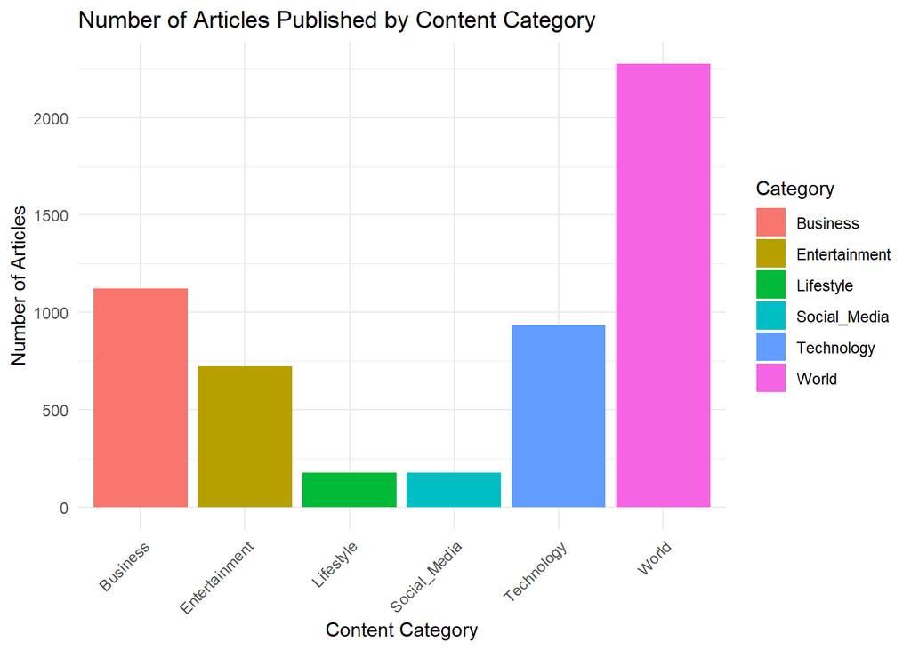

Le graphique illustre la répartition des articles publiés par catégorie de contenu sur Mashable. La catégorie ‘World’ dominent nettement, ce qui témoigne de l’intérêt et de la priorité accordés aux sujets d’actualité mondiale et aux avancées technologiques. La catégorie ‘Business’ suit, reflétant l’importance des informations économiques. Les catégories ‘Entertainment’ et ‘Technologiy’ présentent un nombre inférieur d’articles, ce qui pourrait indiquer une focalisation moins prononcée sur ces sujets ou une concurrence plus intense avec d’autres sources d’informations dans ces domaines. La catégorie ‘Social Media’ et la catégorie ‘Lifestyle’ affichent le moins d’articles, suggérant que bien que Mashable couvre ce sujet, il n’est peut-être pas aussi central dans leur stratégie de contenu que les sujets mondiaux par exemple.

Visualisation des *mesures de subjectivité du contenu* :

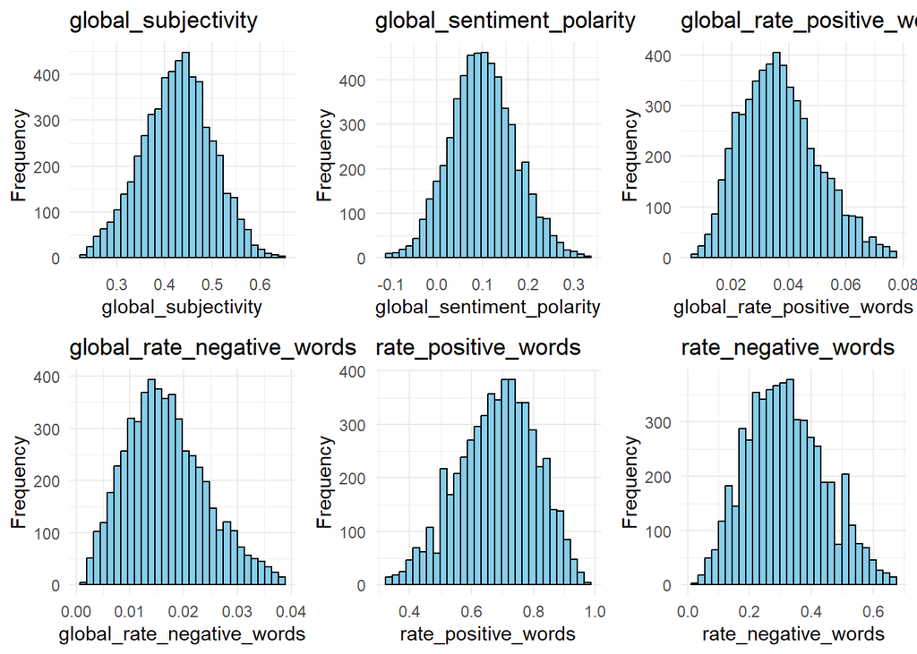

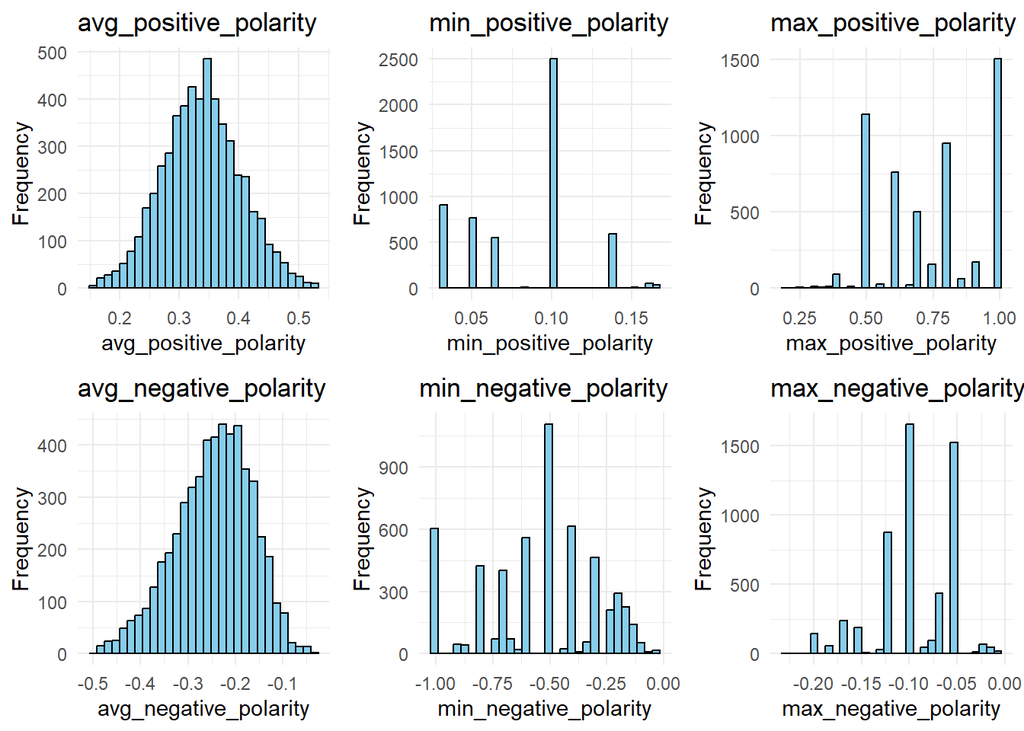

Ces distributions révèlent les nuances du style d’écriture des articles en termes de subjectivité et de polarité. La subjectivité globale, reflétée par une distribution centrée, suggère une tendance des articles à équilibrer les faits et opinions. La polarité globale, avec une distribution centrée proche de zéro, indique que les articles peuvent mélanger des éléments positifs et négatifs, potentiellement pour maintenir l’engagement du lecteur sans pencher excessivement vers des tonalités émotionnelles uniques. Les articles traitants de l’actualité, par exemple, vont voir leur polarité évoluer en fonction de la nouvelle rapportée, qui peut être bonne ou mauvaise.

Visualisation des *mesures de subjectivité du titre* :

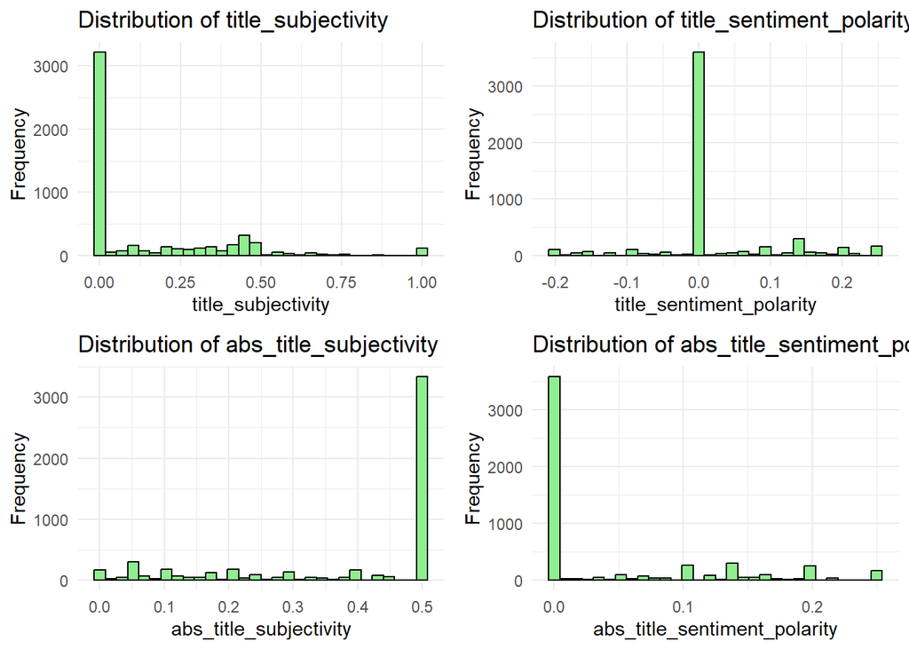

Les titres des articles jouent un rôle significatif dans l’engagement du lecteur et leur décision de partager le contenu. L’analyse montre que la majorité des titres ont une faible subjectivité, indiquant une tendance à des titres plus factuels ou objectifs, peut-être dans le but d’attirer un public plus large en évitant les opinions polarisantes. Toutefois, la polarité des titres, bien que généralement faible, peut permettre de provoquer une émotion chez le lecteur, une stratégie connue pour augmenter le partage d’articles et qui est peut être utilisée ici pour les titres polarisés.

La distribution de l’absolue subjectivité et polarité des titres confirme cette approche en montrant que les titres sont souvent écrits pour être soit nettement objectifs, soit légèrement chargés émotionnellement, évitant les extrêmes qui pourraient détourner certains lecteurs.

# III. Analyses bivariées et de corrélation des variables:

Après avoir examiné individuellement chaque variable pour comprendre leur distribution et leurs caractéristiques intrinsèques, nous allons maintenant approfondir notre analyse en explorant les relations bivariées, en particulier en ce qui concerne notre variable cible, le nombre de partages (shares). Cette phase d’analyse bivariée et de corrélation nous permettra de déceler les interactions potentielles entre les variables et leur influence sur la popularité des articles. Nous chercherons à identifier les facteurs qui sont les plus étroitement liés au nombre de partages, ce qui fournira des aperçus essentiels pour la construction de modèles prédictifs. En examinant comment les variables interagissent deux à deux, nous pouvons commencer à construire une image plus nuancée de la dynamique sous-jacente qui favorise ou inhibe la viralité des articles en ligne.

## A. Analyses bivariées entre dépendante et catégorielle:

**Relation entre le nombre de partage et le jour de publication de l’article**

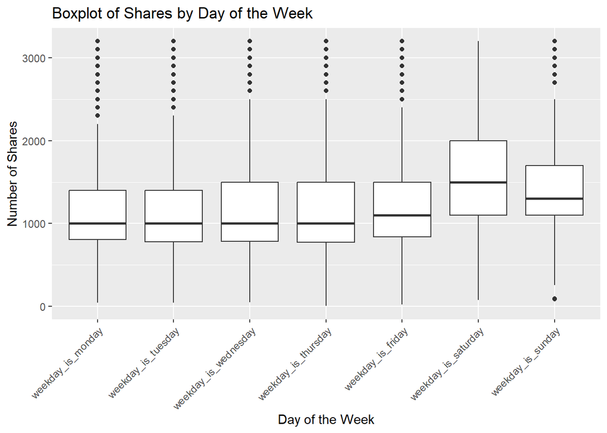

Ce boxplot révèle les différences dans la distribution du nombre de partages des articles en fonction des jours de la semaine. On observe que la médiane reste relativement constante, signalant une tendance similaire dans le nombre de partages, peu importe le jour. Cependant, le samedi semble se démarquer légèrement avec une médiane plus haute, ce qui pourrait indiquer que les lecteurs prennnet plus le temps de partager un article le weekend, quand ils ont le temps de lire.

**Relation entre nombre de partage et le sujet de l’article**

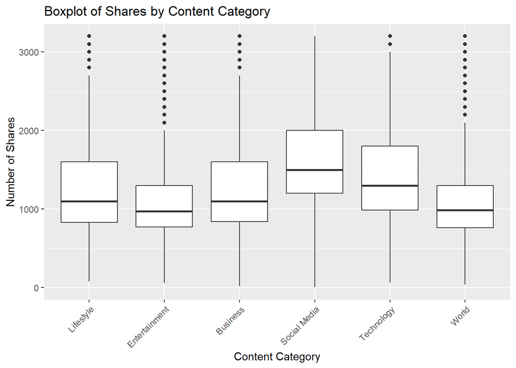

## B. Analyses bivariées des variables explicatives continues

**Relation entre nombre de partages et le nombre de mots dans un article**

Dans le cadre de notre analyse bivariée des variables explicatives continues, nous avons examiné la relation entre le nombre de partages et le nombre de mots dans un article. L’objectif était de déterminer s’il existe une corrélation significative entre la longueur d’un article et sa popularité, mesurée en termes de partages.

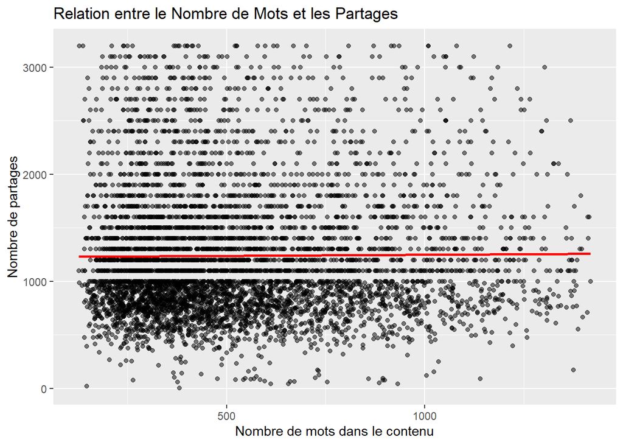

```
##
##  Pearson's product-moment correlation
##
## data:  onp$n_tokens_content and onp$shares
## t = 0.70062, df = 5448, p-value = 0.4836
## alternative hypothesis: true correlation is not equal to 0
## 95 percent confidence interval:
##  -0.01706271  0.03603286
## sample estimates:
##         cor
## 0.009491766
```

La corrélation de Pearson entre le nombre de mots dans le contenu (onp$n_tokens_content) et le nombre de partages (onp$shares) est de 0.0095, ce qui suggère une association très faible entre ces deux variables. En effet, la valeur de p est de 0.5, bien au-dessus du seuil habituel de 0.05, indiquant que cette faible corrélation n’est pas statistiquement significative. De plus, l’intervalle de confiance à 95% pour cette corrélation s’étend de -0.017 à 0.036, incluant zéro, ce qui renforce l’idée que le nombre de mots dans un article n’est pas un prédicteur fiable du nombre de partages.

Ces résultats nous amènent à conclure que la quantité de texte dans un article de Mashable ne semble pas influencer la fréquence à laquelle l’article est partagé.

**Relation entre nombre de partages et le nombre d’images dans un article**

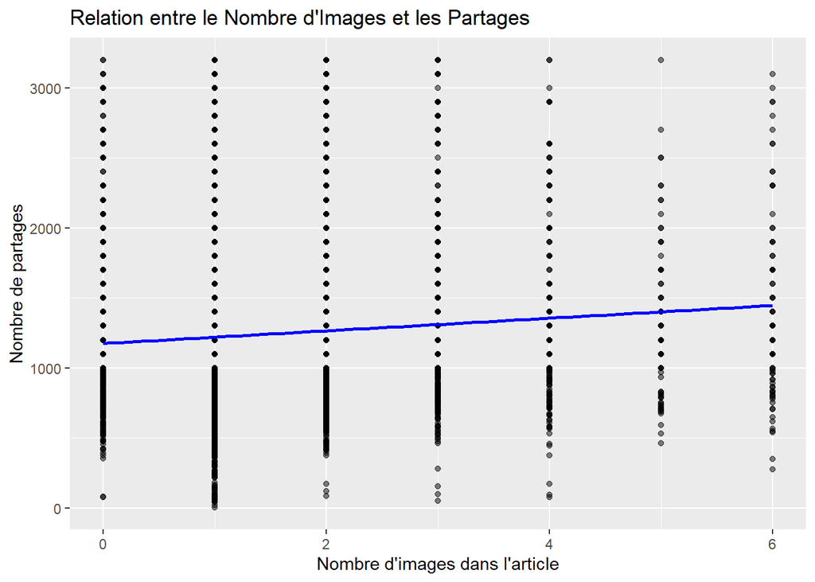

```
##
##  Pearson's product-moment correlation
##
## data:  onp$num_imgs and onp$shares
## t = 5.824, df = 5448, p-value = 6.074e-09
## alternative hypothesis: true correlation is not equal to 0
## 95 percent confidence interval:
##  0.0522192 0.1049912
## sample estimates:
##        cor
## 0.07866032
```

L’analyse de corrélation de Pearson indique une corrélation positive légère mais significative (cor = 0.079) entre ces deux variables, avec une valeur p proche de zéro (p = 6e-09), ce qui suggère que cette association n’est pas due au hasard.

La présence d’images dans les articles semble avoir un effet modeste sur la probabilité d’être partagés, ce qui pourrait être interprété comme un élément d’attraction visuelle pour les lecteurs. Néanmoins, la force de cette relation reste faible, comme le montre la plage de l’intervalle de confiance à 95% (0.052 à 0.105), ce qui implique que d’autres facteurs pourraient également jouer un rôle important dans la popularité des articles sur les réseaux sociaux.

Le graphique adjacent offre une visualisation claire de la dispersion des données, où l’on observe une légère tendance ascendante, soulignée par la ligne de tendance bleue, à mesure que le nombre d’images augmente.

**Relation entre nombre de partages et les variables de subjectivité des articles**

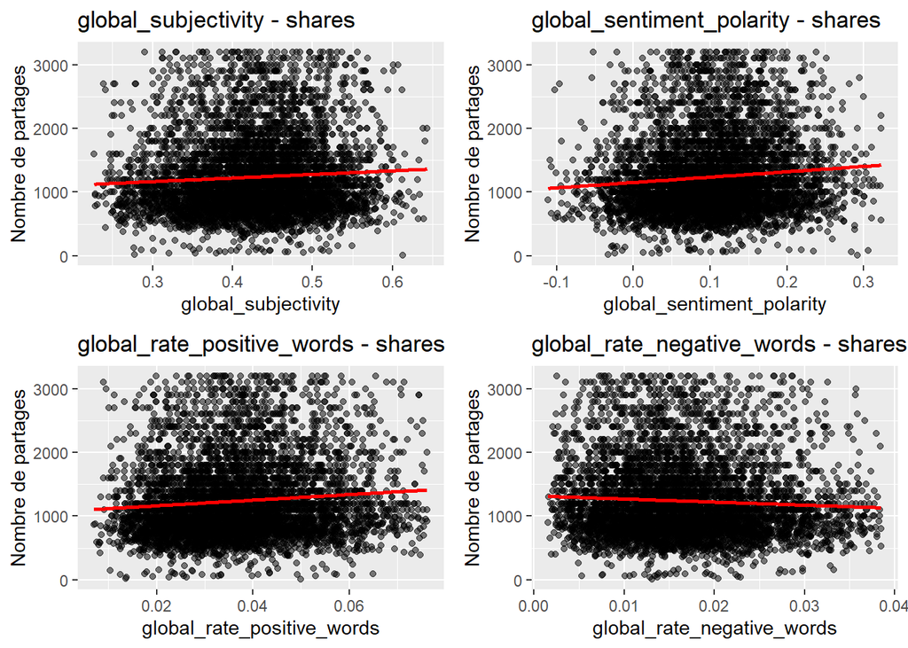

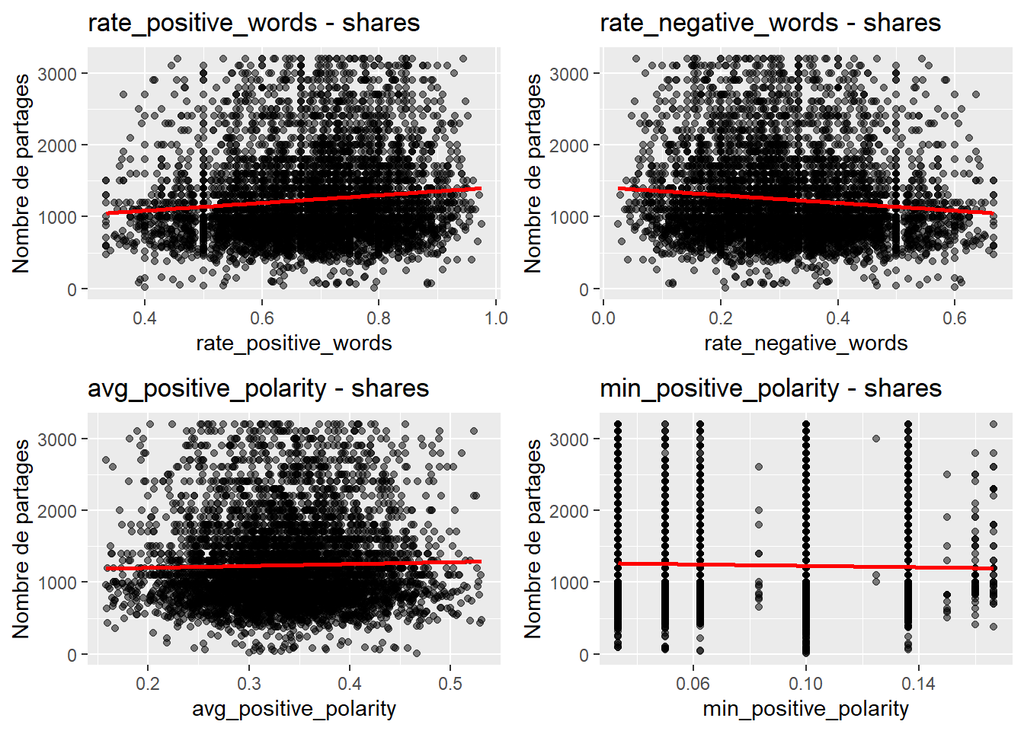

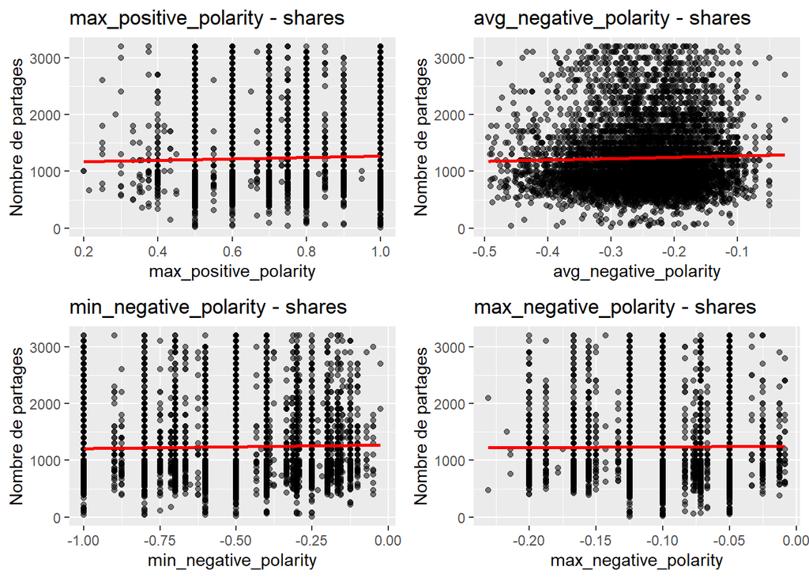

```
##        global_subjectivity  global_sentiment_polarity
##                0.066472155                0.096738796
## global_rate_positive_words global_rate_negative_words
##                0.095218019               -0.057993545
##        rate_positive_words        rate_negative_words
##                0.109589778               -0.109589778
##      avg_positive_polarity      min_positive_polarity
##                0.027947623               -0.028184504
##      max_positive_polarity      avg_negative_polarity
##                0.039160880                0.031626235
##      min_negative_polarity      max_negative_polarity
##                0.026018454                0.008395455
```

L’analyse des relations entre le nombre de partages et les mesures de subjectivité et de polarité des articles révèle des tendances intéressantes. La subjectivité globale semble avoir une dispersion équilibrée de partages, sans une corrélation forte apparente, suggérant que le degré de subjectivité n’influence pas de manière significative la viralité. La polarité sentimentale, qu’elle soit positive ou négative, présente également une distribution uniforme des partages, ce qui indique que l’émotion véhiculée dans le contenu de l’article ne prédétermine pas son succès en termes de partages. Des taux élevés de mots positifs ou négatifs ne garantissent pas non plus une plus grande popularité. Enfin, les valeurs extrêmes de polarité, aussi bien positives que négatives, ne montrent pas de lien direct avec une augmentation des partages. Ces observations suggèrent que les aspects émotionnels et subjectifs des articles, bien qu’importants pour l’engagement des lecteurs, ne sont pas des prédicteurs déterminants de la propagation sur les réseaux sociaux.

## C. Analyses de la corrélation

Pour procéder à l’analyse de la correlation, on opte pour un corrplot, mais vu le grand nombre des variables, on s’intéresse aux variables les plus corrélées qui peuvent biaiser notre modèle.

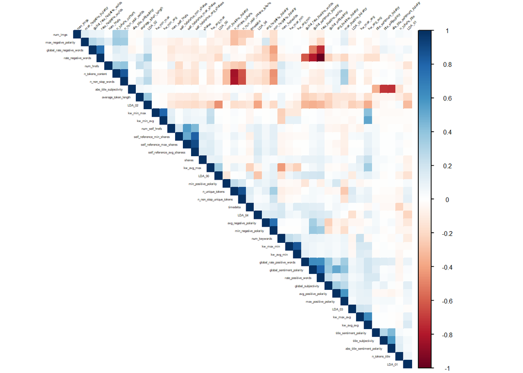

La multicollinéarité dans les modèles de régression se réfère à une situation où deux ou plusieurs variables prédictives dans un modèle sont fortement corrélées, ce qui rend difficile l’estimation des relations entre chaque variable prédictive et la variable cible.

Une corrélation supérieure à **0.7** : Un seuil souvent cité est une corrélation de 0.7 entre deux variables indépendantes. Si la corrélation entre deux variables dépasse ce seuil, cela peut indiquer une forte collinéarité qui pourrait influencer négativement le modèle.

Pour ce cas on essaie à partir du 1er graphique de correlation d’extraire les variables dont la correlation est supérieure à 0.7 pour diminuer le risque de la multicolinéarité. Il s’agit ici de les réperer afin de pouvoir les exclure plus tard.

```
## n_tokens_content - n_unique_tokens :  -0.8301874
## n_tokens_content - n_non_stop_words :  0.8458797
## n_unique_tokens - n_non_stop_words :  -0.8118109
## n_unique_tokens - n_non_stop_unique_tokens :  0.8753188
## kw_max_min - kw_avg_min :  0.8504724
## kw_min_max - kw_min_avg :  0.7968441
## self_reference_min_shares - self_reference_avg_sharess :  0.8133756
## self_reference_max_shares - self_reference_avg_sharess :  0.8977588
## global_sentiment_polarity - rate_positive_words :  0.7971246
## global_rate_negative_words - rate_positive_words :  -0.7452797
## global_sentiment_polarity - rate_negative_words :  -0.7971246
## global_rate_negative_words - rate_negative_words :  0.7452797
## rate_positive_words - rate_negative_words :  -1
## avg_negative_polarity - min_negative_polarity :  0.7578164
## title_subjectivity - abs_title_subjectivity :  -0.7109688
## abs_title_subjectivity - abs_title_sentiment_polarity :  -0.7268337
```

## D. Le facteur d’inflation de la variance - VIF

Le facteur d’inflation de la variance (VIF) est un outil servant à évaluer la force de la corrélation entre les variables indépendantes dans un modèle de régression multiple. Il quantifie à quel point la variance d’un estimateur de régression est augmentée en raison de la multicollinéarité. Un VIF élevé indique qu’une variable indépendante est fortement linéairement corrélée avec une ou plusieurs autres variables indépendantes, ce qui peut affecter la fiabilité des coefficients estimés et affaiblir l’interprétabilité du modèle.

Pour notre projet, la compréhension et la réduction de la multicollinéarité à travers le VIF sont essentielles car elles nous permettent de construire des modèles de prédiction plus stables et fiables. Des valeurs de VIF élevées dans notre modèle pourraient suggérer que nous devons repenser notre sélection de variables ou utiliser des méthodes de régularisation telles que la régression Ridge ou Lasso, qui peuvent aider à atténuer l’impact de la multicollinéarité.

L’objectif sera donc de veiller à ce que les VIFs de toutes les variables dans notre modèle final soient en dessous du seuil critique de 10, ce qui indique une absence de problèmes sérieux de multicollinéarité. Cela renforcera la confiance dans nos prédictions de la popularité des articles en ligne, telles que mesurées par le nombre de partages (shares), et dans les recommandations stratégiques dérivées de notre analyse.

| Observations | 5450 |
| --- | --- |
| Dependent variable | shares |
| Type | OLS linear regression |

| F(48,5401) | 21.65 |
| --- | --- |
| R² | 0.16 |
| Adj. R² | 0.15 |

|  | Est. | S.E. | t val. | p | VIF |
| --- | --- | --- | --- | --- | --- |
| (Intercept) | 403.28 | 292.13 | 1.38 | 0.17 | NA |
| timedelta | 0.02 | 0.08 | 0.27 | 0.78 | 2.96 |
| n_tokens_title | -2.03 | 3.88 | -0.52 | 0.60 | 1.12 |
| n_tokens_content | -0.08 | 0.06 | -1.33 | 0.18 | 5.17 |
| n_unique_tokens | -361.78 | 354.87 | -1.02 | 0.31 | 11.22 |
| n_non_stop_unique_tokens | 145.45 | 262.96 | 0.55 | 0.58 | 5.71 |
| num_hrefs | 8.14 | 1.93 | 4.22 | 0.00 | 1.44 |
| num_self_hrefs | -4.13 | 4.88 | -0.85 | 0.40 | 1.67 |
| num_imgs | 43.34 | 7.94 | 5.46 | 0.00 | 1.23 |
| num_videos | 35.64 | 14.13 | 2.52 | 0.01 | 1.09 |
| average_token_length | -8.78 | 37.40 | -0.23 | 0.81 | 1.46 |
| num_keywords | 9.43 | 5.47 | 1.72 | 0.08 | 1.65 |
| data_channel_is_lifestyle | -62.70 | 47.19 | -1.33 | 0.18 | 1.21 |
| data_channel_is_entertainment | -119.87 | 28.67 | -4.18 | 0.00 | 1.61 |
| data_channel_is_bus | 130.89 | 26.11 | 5.01 | 0.00 | 1.90 |
| data_channel_is_socmed | 370.62 | 47.35 | 7.83 | 0.00 | 1.19 |
| data_channel_is_tech | 228.87 | 26.59 | 8.61 | 0.00 | 1.71 |
| kw_min_min | -10.55 | 6.09 | -1.73 | 0.08 | 2.74 |
| kw_max_min | 0.05 | 0.04 | 1.25 | 0.21 | 4.14 |
| kw_avg_min | -0.08 | 0.15 | -0.55 | 0.58 | 4.36 |
| kw_min_max | 0.00 | 0.00 | 0.96 | 0.34 | 3.15 |
| kw_avg_max | -0.00 | 0.00 | -0.50 | 0.62 | 2.18 |
| kw_min_avg | -0.08 | 0.02 | -3.99 | 0.00 | 4.15 |
| kw_max_avg | -0.04 | 0.01 | -3.00 | 0.00 | 2.60 |
| kw_avg_avg | 0.32 | 0.03 | 10.30 | 0.00 | 4.34 |
| self_reference_min_shares | 0.06 | 0.03 | 2.26 | 0.02 | 11.69 |
| self_reference_max_shares | -0.00 | 0.02 | -0.04 | 0.97 | 21.62 |
| self_reference_avg_sharess | 0.01 | 0.04 | 0.16 | 0.87 | 44.92 |
| weekday_is_monday | -288.87 | 38.86 | -7.43 | 0.00 | 3.78 |
| weekday_is_tuesday | -317.62 | 38.47 | -8.26 | 0.00 | 4.00 |
| weekday_is_wednesday | -309.22 | 38.76 | -7.98 | 0.00 | 3.84 |
| weekday_is_thursday | -324.51 | 38.62 | -8.40 | 0.00 | 3.93 |
| weekday_is_friday | -213.18 | 39.75 | -5.36 | 0.00 | 3.36 |
| weekday_is_saturday | 160.24 | 48.13 | 3.33 | 0.00 | 1.92 |
| global_subjectivity | 159.39 | 132.73 | 1.20 | 0.23 | 1.58 |
| global_sentiment_polarity | -825.65 | 338.33 | -2.44 | 0.01 | 9.77 |
| global_rate_positive_words | 660.09 | 1558.92 | 0.42 | 0.67 | 7.33 |
| global_rate_negative_words | -66.88 | 3194.61 | -0.02 | 0.98 | 9.47 |
| rate_positive_words | 499.58 | 241.68 | 2.07 | 0.04 | 15.50 |
| avg_positive_polarity | 266.02 | 221.73 | 1.20 | 0.23 | 3.56 |
| min_positive_polarity | 86.53 | 254.67 | 0.34 | 0.73 | 1.29 |
| max_positive_polarity | -1.52 | 55.44 | -0.03 | 0.98 | 2.05 |
| avg_negative_polarity | 234.81 | 189.61 | 1.24 | 0.22 | 3.97 |
| min_negative_polarity | -52.03 | 59.90 | -0.87 | 0.39 | 3.93 |
| max_negative_polarity | 385.04 | 229.22 | 1.68 | 0.09 | 1.51 |
| title_subjectivity | 67.79 | 45.93 | 1.48 | 0.14 | 2.10 |
| title_sentiment_polarity | 86.06 | 101.53 | 0.85 | 0.40 | 1.30 |
| abs_title_subjectivity | -50.29 | 76.19 | -0.66 | 0.51 | 3.01 |
| abs_title_sentiment_polarity | -146.89 | 157.59 | -0.93 | 0.35 | 2.38 |

Standard errors: OLS

Dans le cadre de l’élaboration d’un modèle de prédiction efficace, il est crucial d’épurer notre ensemble de données des variables redondantes ou inutiles. Pour ce faire, nous avons d’abord identifié les variables présentant un facteur d’inflation de la variance (VIF) supérieur à 10, ce qui suggère une multicollinéarité problématique. Les variables suivantes sont donc exclues de notre modèles.

*n_unique_tokens* *self_reference_min_shares* *self_reference_max_shares* *self_reference_avg_shares* *rate_positive_words*

| Observations | 5450 |
| --- | --- |
| Dependent variable | shares |
| Type | OLS linear regression |

| F(42,5407) | 22.86 |
| --- | --- |
| R² | 0.15 |
| Adj. R² | 0.14 |

|  | Est. | S.E. | t val. | p | VIF |
| --- | --- | --- | --- | --- | --- |
| (Intercept) | 843.45 | 242.29 | 3.48 | 0.00 | NA |
| timedelta | 0.01 | 0.08 | 0.07 | 0.94 | 2.96 |
| n_tokens_title | -0.94 | 3.89 | -0.24 | 0.81 | 1.11 |
| n_tokens_content | -0.06 | 0.05 | -1.32 | 0.19 | 2.87 |
| n_non_stop_unique_tokens | -131.97 | 150.15 | -0.88 | 0.38 | 1.84 |
| num_hrefs | 5.45 | 1.87 | 2.91 | 0.00 | 1.35 |
| num_self_hrefs | 2.51 | 4.11 | 0.61 | 0.54 | 1.17 |
| num_imgs | 45.46 | 7.97 | 5.71 | 0.00 | 1.22 |
| num_videos | 38.64 | 14.17 | 2.73 | 0.01 | 1.09 |
| average_token_length | -25.93 | 36.15 | -0.72 | 0.47 | 1.35 |
| num_keywords | 9.36 | 5.48 | 1.71 | 0.09 | 1.64 |
| data_channel_is_lifestyle | -51.94 | 47.41 | -1.10 | 0.27 | 1.20 |
| data_channel_is_entertainment | -123.88 | 28.46 | -4.35 | 0.00 | 1.57 |
| data_channel_is_bus | 134.80 | 26.21 | 5.14 | 0.00 | 1.89 |
| data_channel_is_socmed | 379.90 | 47.56 | 7.99 | 0.00 | 1.19 |
| data_channel_is_tech | 242.95 | 26.58 | 9.14 | 0.00 | 1.69 |
| kw_min_min | -11.93 | 6.11 | -1.95 | 0.05 | 2.73 |
| kw_max_min | 0.05 | 0.04 | 1.12 | 0.26 | 4.13 |
| kw_avg_min | -0.07 | 0.15 | -0.47 | 0.64 | 4.35 |
| kw_min_max | 0.00 | 0.00 | 0.94 | 0.35 | 3.15 |
| kw_avg_max | -0.00 | 0.00 | -0.38 | 0.70 | 2.17 |
| kw_min_avg | -0.08 | 0.02 | -4.28 | 0.00 | 4.15 |
| kw_max_avg | -0.04 | 0.01 | -2.98 | 0.00 | 2.59 |
| kw_avg_avg | 0.34 | 0.03 | 10.65 | 0.00 | 4.32 |
| weekday_is_monday | -295.84 | 39.03 | -7.58 | 0.00 | 3.77 |
| weekday_is_tuesday | -318.59 | 38.66 | -8.24 | 0.00 | 4.00 |
| weekday_is_wednesday | -313.10 | 38.95 | -8.04 | 0.00 | 3.84 |
| weekday_is_thursday | -327.12 | 38.80 | -8.43 | 0.00 | 3.92 |
| weekday_is_friday | -219.19 | 39.94 | -5.49 | 0.00 | 3.35 |
| weekday_is_saturday | 156.30 | 48.38 | 3.23 | 0.00 | 1.92 |
| global_subjectivity | 178.66 | 133.03 | 1.34 | 0.18 | 1.57 |
| global_sentiment_polarity | -637.81 | 328.29 | -1.94 | 0.05 | 9.09 |
| global_rate_positive_words | 2588.75 | 1127.04 | 2.30 | 0.02 | 3.79 |
| global_rate_negative_words | -5704.12 | 1860.83 | -3.07 | 0.00 | 3.18 |
| avg_positive_polarity | 223.59 | 219.41 | 1.02 | 0.31 | 3.44 |
| min_positive_polarity | -27.37 | 254.70 | -0.11 | 0.91 | 1.28 |
| max_positive_polarity | -2.58 | 55.63 | -0.05 | 0.96 | 2.04 |
| avg_negative_polarity | 214.81 | 190.31 | 1.13 | 0.26 | 3.96 |
| min_negative_polarity | -45.46 | 60.21 | -0.75 | 0.45 | 3.92 |
| max_negative_polarity | 329.50 | 229.08 | 1.44 | 0.15 | 1.49 |
| title_subjectivity | 82.41 | 39.47 | 2.09 | 0.04 | 1.53 |
| title_sentiment_polarity | 124.48 | 101.98 | 1.22 | 0.22 | 1.30 |
| abs_title_sentiment_polarity | -100.66 | 135.75 | -0.74 | 0.46 | 1.74 |

Standard errors: OLS

Suite à cela on se retrouve avec une regression avec un VIF<10, et une non colinéarité entre les variables pour optimiser notre modèle de prédiction et éviter le surapprentissage.

## E. Etude de la non linéarité:

Pour étudier la non linéarité, on dessine un graphique de correlation pour la variable shares, et on essaie de visualiser la courbe de correlation.

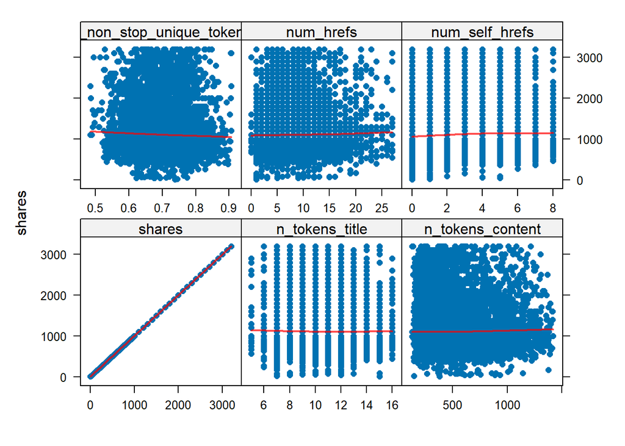

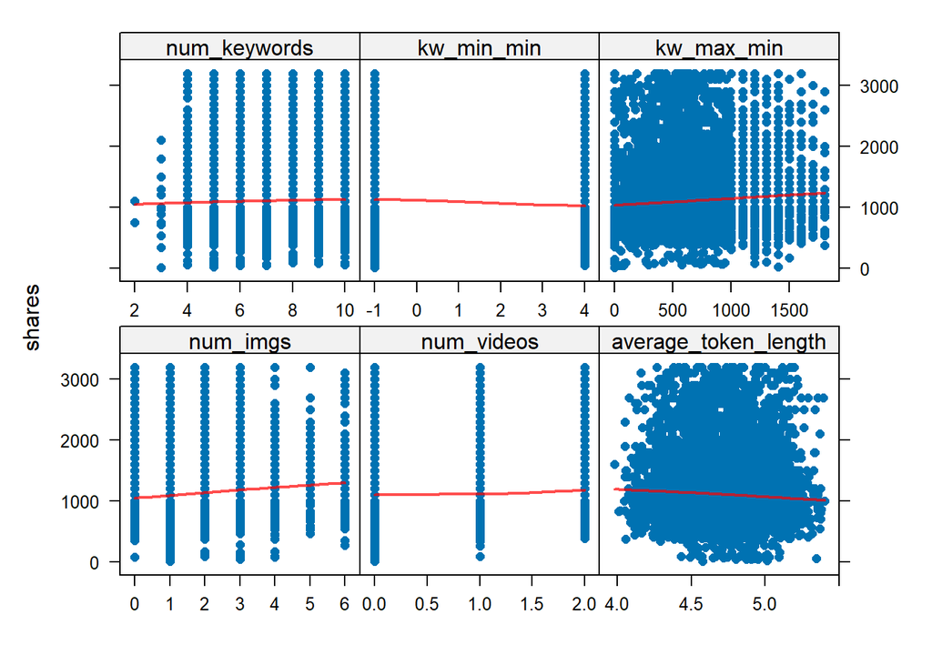

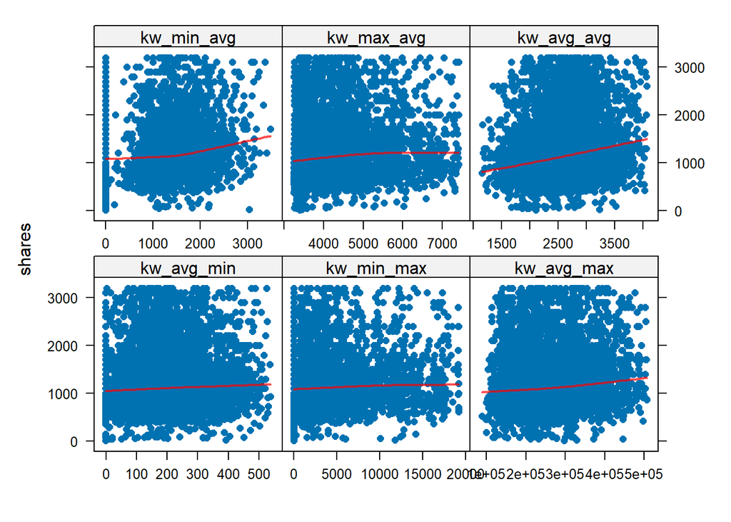

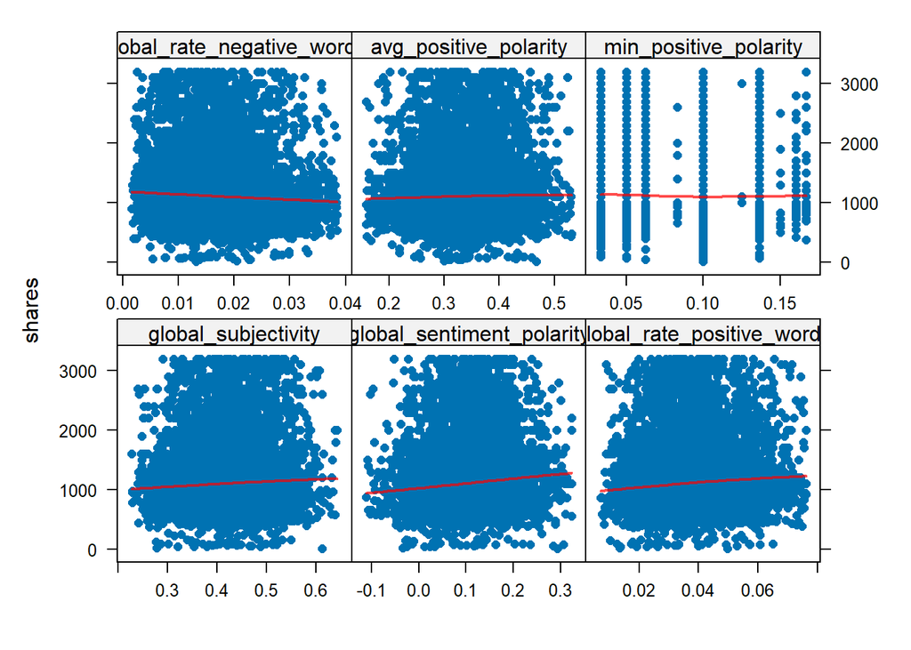

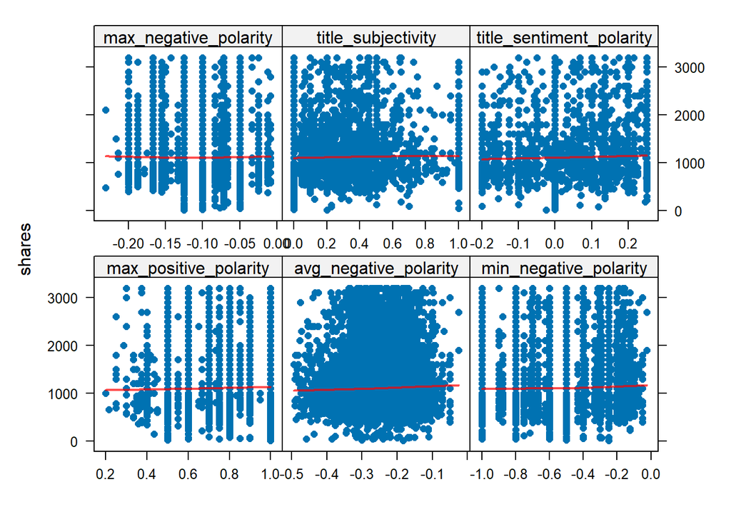

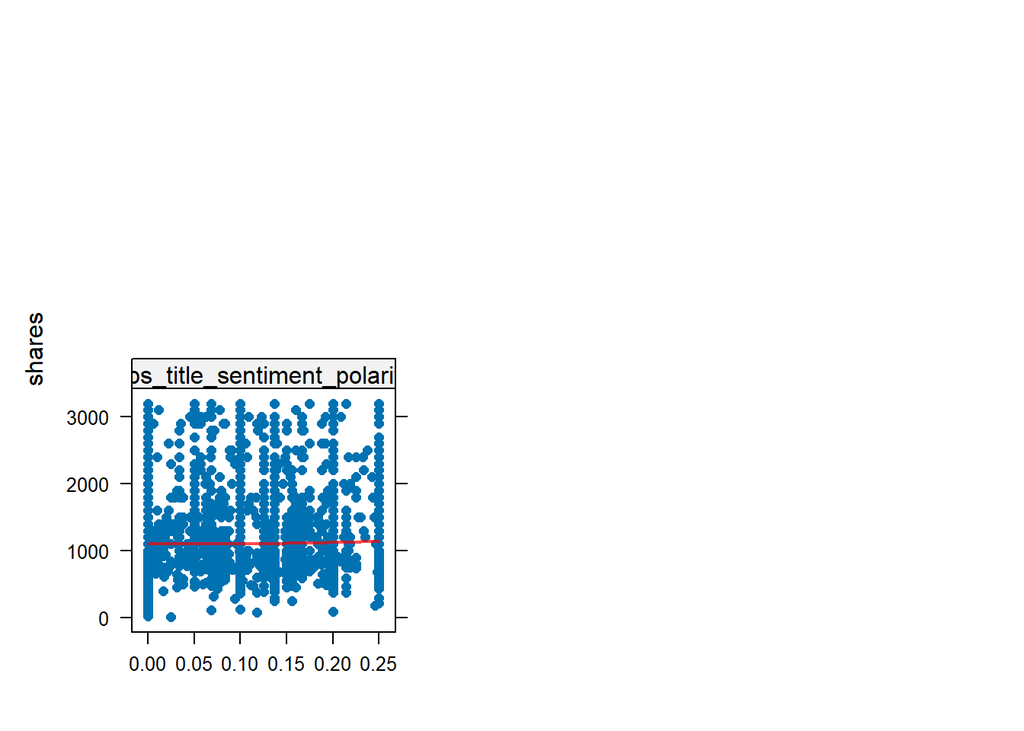

D’après les résultats, on ne se retrouve pas avec une variable non linéaire mis à part kw_min_avg. Par soucis de rigueur on pourra prendre en compte d’autres variable pour la méthode spline, mais cela reste négligeable.

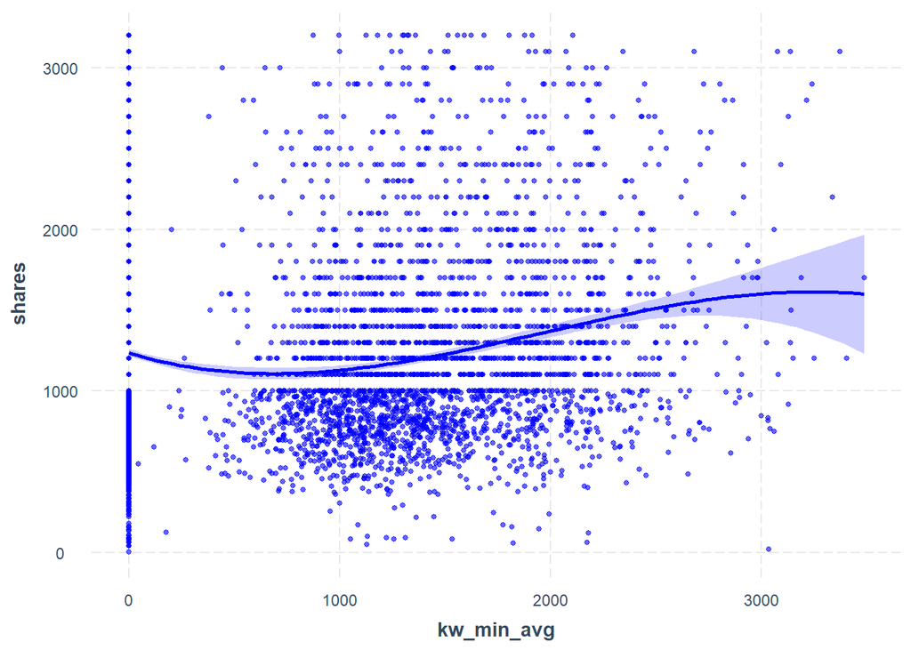

```r
reg1 <- lm(shares ~ bs(kw_min_avg, df = 3), data = onpc)
effect_plot(reg1, data = onpc, pred = kw_min_avg,
            interval = TRUE, robust = "HC1",
            colors = "blue", line.thickness = 1,
            plot.points = TRUE, pch = ".",
            point.size = 1)
```

Pour la relation non linéaire entre *shares* et *kw_min_avg*,l’utilisation d’une spline de degré 3 semble être pertinente. En réalité, cela revient à modéliser la relation par un polynome du troisième degrés.

Ainsi,

- L’exploration des données nous a amené à déceler des relations non linéaires entre la variable dépendante et les variables explicatives.
- Certaines des variables explicatives étaient très corrélées entre elles. Cela était source de colinéarité. Nous avons donc supprimé les variables en question.
- Parmi l’ensemble des variables explicatives conservées, une seule sera introduite à l’aide d’une relation non linéaire.

Après cette analyse, nous obtenons la base de donnée suivante.

```
## # A tibble: 6 × 45
##   timedelta n_tokens_title n_tokens_content n_non_stop_unique_tokens num_hrefs
##       <dbl>          <dbl>            <dbl>                    <dbl>     <dbl>
## 1       553              7              245                    0.763         8
## 2       553             10              436                    0.664         9
## 3       553             12              245                    0.771         8
## 4       553              8              178                    0.798         7
## 5       553              7             1370                    0.670         7
## 6       553              9              244                    0.732         7
## # ℹ 40 more variables: num_self_hrefs <dbl>, num_imgs <dbl>, num_videos <dbl>,
## #   average_token_length <dbl>, num_keywords <dbl>,
## #   data_channel_is_lifestyle <dbl>, data_channel_is_entertainment <dbl>,
## #   data_channel_is_bus <dbl>, data_channel_is_socmed <dbl>,
## #   data_channel_is_tech <dbl>, data_channel_is_world <dbl>, kw_min_min <dbl>,
## #   kw_max_min <dbl>, kw_avg_min <dbl>, kw_min_max <dbl>, kw_avg_max <dbl>,
## #   kw_min_avg <dbl>, kw_max_avg <dbl>, kw_avg_avg <dbl>, …
```

# IV. Des modèles prédictifs pour le nombre de partage des articles

L’objectif de notre étude est de développer des modèles prédictifs pour estimer le nombre de partages des articles, un indicateur clé de leur popularité en ligne. Nous employons une gamme de techniques avancées, incluant les arbres de régression, les forêts aléatoires, les modèles additifs généralisés (GAM) et le boosting, choisies pour leur efficacité à capturer la complexité des données. Notre méthodologie vise à équilibrer la précision prédictive avec l’interprétabilité, permettant ainsi d’identifier les facteurs déterminants de la viralité des contenus. L’objectif sera de voir quelle sont les caractéristiques de l’article qui influencent le nombre de partages.

## A. Arbres regressionnels:

L’arbre de décision régressif constitue une méthode fondamentale dans l’arsenal des modèles prédictifs, offrant une approche visuelle et intuitive pour la compréhension des relations complexes entre variables. Ce modèle construit une structure arborescente où chaque nœud représente une décision basée sur une variable explicative, et chaque feuille correspond à une valeur prédictive du nombre de partages. Son principal avantage réside dans sa simplicité d’interprétation, permettant même aux non-statisticiens de saisir facilement les critères de décision.

Le processus de “pruning” (élagage) des arbres est crucial pour éviter le surapprentissage, en réduisant la complexité de l’arbre pour améliorer sa généralisation sur de nouvelles données. Cette étape optimise l’équilibre entre biais et variance, contribuant à la robustesse du modèle.

L’extension vers les “bagged trees” (arbres en sac) amplifie cette robustesse en combinant les prédictions de multiples arbres construits sur des sous-ensembles du jeu de données, réduisant la variance sans augmenter le biais. Cette méthode de forêt aléatoire offre une amélioration significative de la précision prédictive par rapport à un seul arbre de décision.

### A.1. Arbre de décision regressionnel:

```r
library(tree)

# Création de la formule avec les variables spécifiées
formula <- as.formula(paste("log(shares) ~", paste(c("timedelta", "n_tokens_title", "n_tokens_content", "n_non_stop_unique_tokens", "num_hrefs", "num_self_hrefs", "num_imgs", "num_videos", "average_token_length", "num_keywords", "data_channel_is_lifestyle", "data_channel_is_entertainment", "data_channel_is_bus", "data_channel_is_socmed", "data_channel_is_tech", "kw_min_min", "kw_max_min", "kw_avg_min", "kw_min_max", "kw_avg_max", "kw_min_avg", "kw_max_avg", "kw_avg_avg", "weekday_is_monday", "weekday_is_tuesday", "weekday_is_wednesday", "weekday_is_thursday", "weekday_is_friday", "weekday_is_saturday", "global_subjectivity", "global_sentiment_polarity", "global_rate_positive_words", "global_rate_negative_words", "avg_positive_polarity", "min_positive_polarity", "max_positive_polarity", "avg_negative_polarity", "min_negative_polarity", "max_negative_polarity", "title_subjectivity", "title_sentiment_polarity", "abs_title_sentiment_polarity"), collapse = " + ")))

tree_model <- tree(formula, data = onp1, mindev = 0.3)

summary(tree_model)
```

```
##
## Regression tree:
## tree(formula = formula, data = onp1, mindev = 0.3)
## Variables actually used in tree construction:
## character(0)
## Number of terminal nodes:  1
## Residual mean deviance:  0.2602 = 1418 / 5449
## Distribution of residuals:
##      Min.   1st Qu.    Median      Mean   3rd Qu.      Max.
## -5.394000 -0.303600 -0.000023  0.000000  0.310100  1.068000
```

Sur ce premier modèle on se retrouve avec un seul noeud, ce qui n’est pas du tout logique pour un modele de prédiction.

C’est pour cela qu’on s’interesse à un modele de prunning où on essaie de retouver un nombre de noeud optimal.

### A.2 Prunning

```r
library(caret)
library(doParallel)
library(rpart)

# Définir le nombre de cœurs à utiliser
nrcore <- detectCores() - 1
cl <- makeCluster(nrcore)
registerDoParallel(cl)

bootTunes <- 5
bootControl <- trainControl(method = "boot",
                            number = 50,
                            savePredictions = TRUE,
                            seeds = NULL)

cp_values <- seq(from = 0.01, to = 0.1, length.out = bootTunes)
# Ajuster le modèle
set.seed(123) # Fixer une graine pour la reproductibilité
btree <- train(formula, data = onp1,  method = "rpart",
               trControl = bootControl,
               tuneGrid = expand.grid(cp = cp_values))
# Arrêter le cluster parallèle
stopCluster(cl)
registerDoSEQ()

# Afficher le résumé du modèle
print(btree)
```

```
## CART
##
## 5450 samples
##   42 predictor
##
## No pre-processing
## Resampling: Bootstrapped (50 reps)
## Summary of sample sizes: 5450, 5450, 5450, 5450, 5450, 5450, ...
## Resampling results across tuning parameters:
##
##   cp      RMSE       Rsquared    MAE
##   0.0100  0.4946062  0.06885849  0.3687419
##   0.0325  0.5010571  0.03287358  0.3740294
##   0.0550  0.5089517         NaN  0.3809083
##   0.0775  0.5089517         NaN  0.3809083
##   0.1000  0.5089517         NaN  0.3809083
##
## RMSE was used to select the optimal model using the smallest value.
## The final value used for the model was cp = 0.01.
```

Les résultats obtenus à partir de la procédure de prunning avec différentes valeurs de complexité de paramètre (*cp*) montre que le modèle avec le *cp* = 0.01 offre les performances optimales en termes de RMSE (Root Mean Squared Error), avec une valeur de 0.4946062. Cela indique que ce niveau de complexité permet d’obtenir le meilleur équilibre entre ajustement du modèle et généralisation aux données non vues, en minimisant l’erreur de prédiction.

Les valeurs de RMSE augmentent avec les valeurs *cp* plus élevées, ce qui suggère qu’une complexité réduite du modèle (plus grand élagage de l’arbre) entraîne une détérioration de la précision des prédictions. Les valeurs de Rsquared sont disponibles uniquement pour les modèles avec les valeurs *cp* les plus faibles, indiquant une certaine capacité du modèle à expliquer la variabilité des données, bien que cette capacité diminue avec l’augmentation de *cp*.

L’absence de valeurs Rsquared pour les valeurs plus élevées de *cp* indique également que ces modèles sont potentiellement trop simplifiés pour capturer les relations significatives entre les variables explicatives et la variable dépendante. En conséquence, le modèle choisi avec *cp* = 0.01 semble offrir un compromis optimal entre la complexité du modèle et sa capacité à prédire avec précision le nombre de partages des articles, en se basant sur le critère de sélection du RMSE le plus faible.

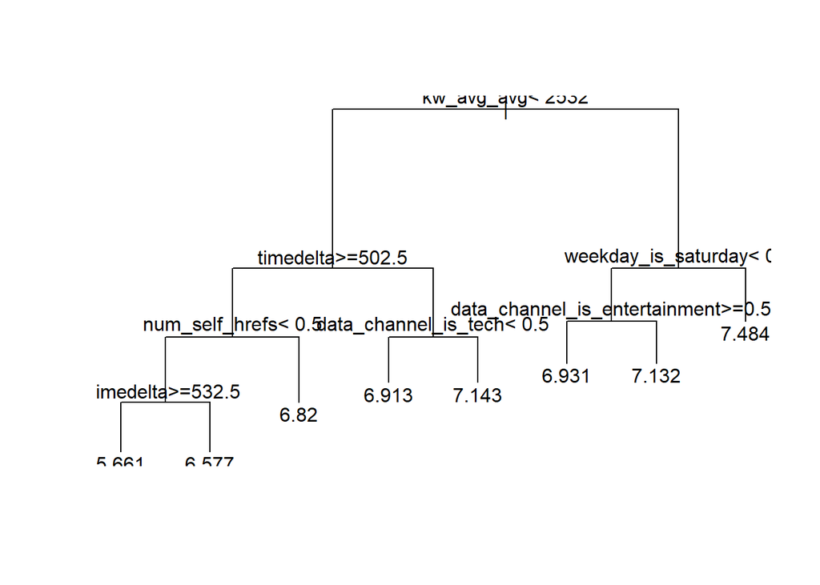

```r
library(caret)
library(rpart)
library(doParallel)

nrcore <- detectCores() - 1
cl <- makeCluster(nrcore)
registerDoParallel(cl)


bootControl <- trainControl(method = "boot",
                            number = 50,
                            savePredictions = TRUE,
                            p = 0.7)
set.seed(123)
btree <- train(formula, data = onp1,  method = "rpart",
               trControl = bootControl,
               tuneGrid = expand.grid(cp = 0.01))

stopCluster(cl)
registerDoSEQ()

# Afficher l'arbre final
plot(btree$finalModel)
text(btree$finalModel)
```